# MUM 2024-25 Modele generatywne

## Założenia

- Modele auto-enkoderów tworzą przestrzeń ukrytą latent, w której generowane są **reprezentacje** danych wejściowych
  - reprezentacje są często niżej wymiarowe, co tworzy wąskie gardło (bottleneck)
  - bottleneck pozwala na usunięcie szumu oraz ekstrakcję jedynie elementów istotnych dla odtwarzania danych
    - na przykład usuniecie szumu
- auto-enkoder jest modelem generatywnym w takim sensie, że uczy się rozkładu danych wejściowych

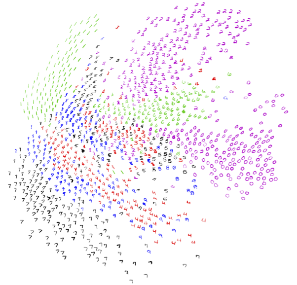

- jaki jest rozkład prawdopodobieństwa przestrzeni latent?
  - powinien odpowiadać rozkładowi przestrzeni danych
    - jest wiele narzędzi do wizualizacji danych, np. UMAP, t-SNE, [SNE](https://distill.pub/2016/misread-tsne/) [[Seeing data as t-SNE and UMAP do]](https://www.nature.com/articles/s41592-024-02301-x)
    - rzutują dane do przestrzeni 2-wymiarowej z maksymalnym **zachowaniem odległości**
  - są obszary, na które rzutowane są prawie wszystkie dane; duże części są puste
  - losując z obszaru gdzie są kody dekoder powinien odkodować obiekt z rozkładu danych
  - co będzie jeśli wylosujemy z obszaru prawie "pustego"?
- dodatkowe zadanie: chcemy, w miarę prosty sposób, móc losować z latent tak, by dekoder zawsze odtwarzał obiekty z rozkładu przestrzeni danych
- niektóre możliwe rozwiązania
  - **generatywne auto-enkodery** można na rozkład punktów w przetrzeni latent nałozyc dodatkowy warunek, by był zgodny z rozkładu danego wzorem zamknietym, tak by można było losować z tego rozkładu
  - **generatory adwersarialne** (przeciwstawne) gdzie dodajemy dodatkowy model informatyczny kontrolujacy poprawność generowania
  - **modele Flow** gdzie funkcja mapowania jest odwracalna
  - **modele dyfuzyjne**